# COVID-19 analysis based on crowdsourced data

[Data source](https://docs.google.com/spreadsheets/d/e/2PACX-1vQU0SIALScXx8VXDX7yKNKWWPKE1YjFlWc6VTEVSN45CklWWf-uWmprQIyLtoPDA18tX9cFDr-aQ9S6/pubhtml)

Paper: Early epidemiological analysis of the coronavirus disease 2019 outbreak based on crowdsourced data: a population-level observational study

Date downloaded: 2020-03-11. Latest data update: 2020-03-09 1PM EST.

DISCLAIMER: Data quality is **very questionable**. As such, any conclusions will be very questionable too. This is meant as a didactic exercise only. Students are invited to find better data and/or keep a very critical mindset while going through the results.

```r
library(tidyverse)
library(broom)
```

# Data preparation

```r
d_realistic_first_shot <- read_csv("covid19.csv")
head(d_realistic_first_shot,5)
```

```
## # A tibble: 5 × 23
##      id case_in reporting…¹ summary locat…² country gender   age sympt…³ if_on…⁴
##   <dbl>   <dbl> <chr>       <chr>   <chr>   <chr>   <chr>  <dbl> <chr>     <dbl>
## 1     1      NA 1/20/2020   First … Shenzh… China   male      66 1/3/20…       0
## 2     2      NA 1/20/2020   First … Shangh… China   female    56 1/15/2…       0
## 3     3      NA 1/21/2020   First … Zhejia… China   male      46 1/4/20…       0
## 4     4      NA 1/21/2020   new co… Tianjin China   female    60 <NA>         NA
## 5     5      NA 1/21/2020   new co… Tianjin China   male      58 <NA>         NA
## # … with 13 more variables: hosp_visit_date <chr>, exposure_start <chr>,
## #   exposure_end <chr>, international_traveler <dbl>, domestic_traveler <dbl>,
## #   traveler <dbl>, `visiting Wuhan` <dbl>, `from Wuhan` <dbl>, death <chr>,
## #   recovered <chr>, symptom <chr>, source <chr>, link <chr>, and abbreviated
## #   variable names ¹reporting_date, ²location, ³symptom_onset,
## #   ⁴if_onset_approximated
```

```r
d_raw <- read_csv(
  file = "covid19.csv",
  col_types = cols(
    id = 'c',
    case_in = 'c',
    age = 'd',
    if_onset_approximated = 'l',
    international_traveler = 'l',
    domestic_traveler = 'l',
    traveler = 'l',
    `visiting Wuhan` = 'l',
    `from Wuhan` = 'l',
    .default = 'c'
  )
)
```

## data cleaning

```r
problems(d_raw)
```

```
## # A tibble: 1 × 5
##     row   col expected           actual file
##   <int> <int> <chr>              <chr>  <chr>
## 1  2225    10 1/0/T/F/TRUE/FALSE 53     /Users/mpaga/Desktop/Data_science/DSTI/…
```

```r
str(d_raw)
```

```
## spc_tbl_ [2,310 × 23] (S3: spec_tbl_df/tbl_df/tbl/data.frame)
##  $ id                    : chr [1:2310] "1" "2" "3" "4" ...
##  $ case_in               : chr [1:2310] NA NA NA NA ...
##  $ reporting_date        : chr [1:2310] "1/20/2020" "1/20/2020" "1/21/2020" "1/21/2020" ...
##  $ summary               : chr [1:2310] "First confirmed imported COVID-19 pneumonia patient in Shenzhen (from Wuhan): male, 66, shenzheng residence, vi"| __truncated__ "First confirmed imported COVID-19 pneumonia patient in Shanghai (from Wuhan): female, 56, Wuhan residence, arri"| __truncated__…
##  $ location              : chr [1:2310] "Shenzhen, Guangdong" "Shanghai" "Zhejiang" "Tianjin" ...
##  $ country               : chr [1:2310] "China" "China" "China" "China" ...
##  $ gender                : chr [1:2310] "male" "female" "male" "female" ...
##  $ age                   : num [1:2310] 66 56 46 60 58 44 34 37 39 56 ...
##  $ symptom_onset         : chr [1:2310] "1/3/2020" "1/15/2020" "1/4/2020" NA ...
##  $ if_onset_approximated : logi [1:2310] FALSE FALSE FALSE NA NA FALSE ...
##  $ hosp_visit_date       : chr [1:2310] "1/11/2020" "1/15/2020" "1/17/2020" "1/19/2020" ...
##  $ exposure_start        : chr [1:2310] "12/29/2019" NA NA NA ...
##  $ exposure_end          : chr [1:2310] "1/4/2020" "1/12/2020" "1/3/2020" NA ...
##  $ international_traveler: logi [1:2310] NA NA NA NA NA NA ...
##  $ domestic_traveler     : logi [1:2310] NA NA NA NA NA NA ...
##  $ traveler              : logi [1:2310] NA NA NA NA NA NA ...
##  $ visiting Wuhan        : logi [1:2310] TRUE FALSE FALSE TRUE FALSE FALSE ...
##  $ from Wuhan            : logi [1:2310] FALSE TRUE TRUE FALSE FALSE TRUE ...
##  $ death                 : chr [1:2310] "0" "0" "0" "0" ...
##  $ recovered             : chr [1:2310] "0" "0" "0" "0" ...
##  $ symptom               : chr [1:2310] NA NA NA NA ...
##  $ source                : chr [1:2310] "Shenzhen Municipal Health Commission" "Official Weibo of Shanghai Municipal Health Commission" "Health Commission of Zhejiang Province" "人民日报官方微博" ...
##  $ link                  : chr [1:2310] "http://wjw.sz.gov.cn/wzx/202001/t20200120_18987787.htm" "https://www.weibo.com/2372649470/IqogQhgfa?from=page_1001062372649470_profile&wvr=6&mod=weibotime&type=comment" "http://www.zjwjw.gov.cn/art/2020/1/21/art_1202101_41786033.html" "https://m.weibo.cn/s…
##  - attr(*, "spec")=
##   .. cols(
##   ..   .default = col_character(),
##   ..   id = col_character(),
##   ..   case_in = col_character(),
##   ..   reporting_date = col_character(),
##   ..   summary = col_character(),
##   ..   location = col_character(),
##   ..   country = col_character(),
##   ..   gender = col_character(),
##   ..   age = col_double(),
##   ..   symptom_onset = col_character(),
##   ..   if_onset_approximated = col_logical(),
##   ..   hosp_visit_date = col_character(),
##   ..   exposure_start = col_character(),
##   ..   exposure_end = col_character(),
##   ..   international_traveler = col_logical(),
##   ..   domestic_traveler = col_logical(),
##   ..   traveler = col_logical(),
##   ..   `visiting Wuhan` = col_logical(),
##   ..   `from Wuhan` = col_logical(),
##   ..   death = col_character(),
##   ..   recovered = col_character(),
##   ..   symptom = col_character(),
##   ..   source = col_character(),
##   ..   link = col_character()
##   .. )
##  - attr(*, "problems")=<externalptr>
```

```r
d_raw <- d_raw[-2224,]
```

```r
table(d_raw$death)
```

```
##
##         0         1  2/1/2020 2/13/2020 2/14/2020 2/19/2020 2/21/2020 2/22/2020
##      1535        42         1         1         1         2         2         2
## 2/23/2020 2/24/2020 2/25/2020 2/26/2020 2/27/2020 2/28/2020 2/29/2020  3/1/2020
##         5         1         2         4         2         1         1         3
##  3/3/2020  3/4/2020  3/6/2020  3/8/2020
##         1         1         1         2
```

```r
table(d_raw$gender, useNA = "always")
```

```
##
## female   male   <NA>
##    604    797    908
```

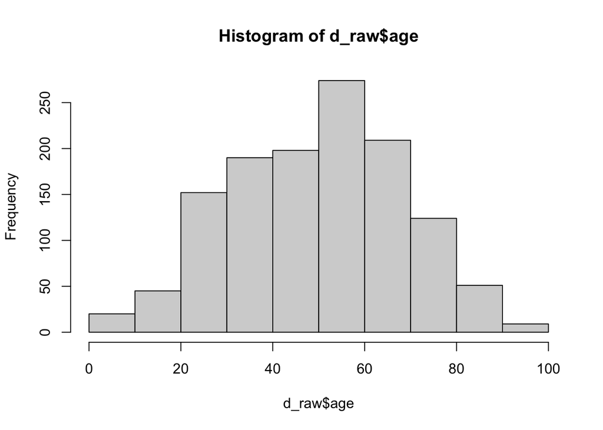

```r
hist(d_raw$age)
abline(v = mean(d_raw$age),col ="red")
abline(v = median(d_raw$age),col ="blue")
```

```r
summary(d_raw$age)
```

```
##    Min. 1st Qu.  Median    Mean 3rd Qu.    Max.    NA's
##    0.25   35.00   53.00   50.22   65.00   96.00    1037
```

```r
x <- NA_character_
y <- c("0", "1/1/2020", "1", NA_character_, "1")
is.na(y)
```

```
## [1] FALSE FALSE FALSE  TRUE FALSE
```

```r
as_date <- function(x) as.Date(x, format = "%m/%d/%y")
d <-
  d_raw |>
  mutate(reporting_date = as_date(reporting_date),
         hosp_visit_date = as_date(hosp_visit_date),
         exposure_start = as_date(exposure_start),
         exposure_end = as_date(exposure_end),
         symptom_onset = as_date(symptom_onset),
         death_status = death != "0",
         death_date = as.Date(ifelse(!death %in% c("0", "1"), as.Date(death, format = "%m/%d/%y", origin = "1970-01-01"), NA), origin = "1970-01-01"),
         gender = factor(gender, levels = c("female", "male")))
```

```r
summary(d)
```

```
##       id              case_in          reporting_date         summary
##  Length:2309        Length:2309        Min.   :2020-01-13   Length:2309
##  Class :character   Class :character   1st Qu.:2020-02-15   Class :character
##  Mode  :character   Mode  :character   Median :2020-02-27   Mode  :character
##                                        Mean   :2020-02-22
##                                        3rd Qu.:2020-03-05
##                                        Max.   :2020-03-10
##                                        NA's   :1
##    location           country             gender         age
##  Length:2309        Length:2309        female:604   Min.   : 0.25
##  Class :character   Class :character   male  :797   1st Qu.:35.00
##  Mode  :character   Mode  :character   NA's  :908   Median :53.00
##                                                     Mean   :50.22
##                                                     3rd Qu.:65.00
##                                                     Max.   :96.00
##                                                     NA's   :1037
##  symptom_onset        if_onset_approximated hosp_visit_date
##  Min.   :2020-01-02   Mode :logical         Min.   :2020-01-01
##  1st Qu.:2020-01-23   FALSE:623             1st Qu.:2020-01-23
##  Median :2020-02-03   TRUE :24              Median :2020-02-04
##  Mean   :2020-02-06   NA's :1662            Mean   :2020-02-07
##  3rd Qu.:2020-02-18                         3rd Qu.:2020-02-21
##  Max.   :2020-12-30                         Max.   :2020-12-31
##  NA's   :1634                               NA's   :1698
##  exposure_start        exposure_end        international_traveler
##  Min.   :2020-01-03   Min.   :2020-01-02   Mode :logical
##  1st Qu.:2020-01-19   1st Qu.:2020-01-20   FALSE:551
##  Median :2020-01-26   Median :2020-01-26   TRUE :192
##  Mean   :2020-02-07   Mean   :2020-02-01   NA's :1566
##  3rd Qu.:2020-02-20   3rd Qu.:2020-02-16
##  Max.   :2020-12-29   Max.   :2020-03-06
##  NA's   :2120         NA's   :1830
##  domestic_traveler  traveler       visiting Wuhan  from Wuhan
##  Mode :logical     Mode :logical   Mode :logical   Mode :logical
##  FALSE:704         FALSE:229       FALSE:1412      FALSE:1445
##  TRUE :53          TRUE :430       TRUE :193       TRUE :156
##  NA's :1552        NA's :1650      NA's :704       NA's :708
##
##
##
##     death            recovered           symptom             source
##  Length:2309        Length:2309        Length:2309        Length:2309
##  Class :character   Class :character   Class :character   Class :character
##  Mode  :character   Mode  :character   Mode  :character   Mode  :character
##
##
##
##
##      link           death_status      death_date
##  Length:2309        Mode :logical   Min.   :2020-02-01
##  Class :character   FALSE:1535      1st Qu.:2020-02-22
##  Mode  :character   TRUE :75        Median :2020-02-25
##                     NA's :699       Mean   :2020-02-24
##                                     3rd Qu.:2020-02-29
##                                     Max.   :2020-03-08
##                                     NA's   :2276
```

# Binary outcome

## Sex impact

### Contingency table

```r
with(d, table(death_status, gender))
```

```
##             gender
## death_status female male
##        FALSE    516  663
##        TRUE      22   47
```

```r
with(d, round(100 * prop.table(table(death_status, gender), 2), 1))
```

```
##             gender
## death_status female male
##        FALSE   95.9 93.4
##        TRUE     4.1  6.6
```

### Logistic regression

```r
d_death_sex <- d |> select(death_status, gender) |> na.omit()
summary(d_death_sex)
```

```
##  death_status       gender
##  Mode :logical   female:538
##  FALSE:1179      male  :710
##  TRUE :69
```

```r
fit_death_sex <- glm(death_status ~ gender, data = d_death_sex, family = "binomial")
summary(fit_death_sex);
```

```
##
## Call:
## glm(formula = death_status ~ gender, family = "binomial", data = d_death_sex)
##
## Deviance Residuals:
##     Min       1Q   Median       3Q      Max
## -0.3701  -0.3701  -0.3701  -0.2890   2.5286
##
## Coefficients:
##             Estimate Std. Error z value Pr(>|z|)
## (Intercept)  -3.1551     0.2176  -14.50   <2e-16 ***
## gendermale    0.5084     0.2649    1.92   0.0549 .
## ---
## Signif. codes:  0 '***' 0.001 '**' 0.01 '*' 0.05 '.' 0.1 ' ' 1
##
## (Dispersion parameter for binomial family taken to be 1)
##
##     Null deviance: 533.65  on 1247  degrees of freedom
## Residual deviance: 529.79  on 1246  degrees of freedom
## AIC: 533.79
##
## Number of Fisher Scoring iterations: 5
```

```r
coef(fit_death_sex)
```

```
## (Intercept)  gendermale
##  -3.1550642   0.5084368
```

beta[0] = -3.16 beta[1] = 0.508 exp(beta[1]) = OR[m vs f]

```r
exp(coef(fit_death_sex)[2])
```

```
## gendermale
##    1.66269
```

The odds of death in males is 1.66 times the odds of death in females.

```r
glm(death_status ~ gender, data = d_death_sex, family = "binomial") |>
  tidy(conf.int = TRUE) |>
  transmute(
    term,
    OR = exp(estimate),
    OR.L = exp(conf.low),
    OR.U = exp(conf.high),
    p.value) |>
  write_csv("model1.csv") |>
  print()
```

```
## # A tibble: 2 × 5
##   term            OR   OR.L   OR.U  p.value
##   <chr>        <dbl>  <dbl>  <dbl>    <dbl>
## 1 (Intercept) 0.0426 0.0270 0.0637 1.28e-47
## 2 gendermale  1.66   1.00   2.84   5.49e- 2
```

The OR of death for males compared to females is 1.66 (95% CI: [1.00-2.84]; pvalue=0.055). At the 5% significance level (5% type-1 error, a.k.a. test size), there’s NO SIGNIFICANT DIFFERFENCE in mortality between men and women.

A better report, ready for excel:

```r
glance(fit_death_sex) |>
  write_tsv("logistic_death_sex_glance.tsv") |>
  print()
```

```
## # A tibble: 1 × 8
##   null.deviance df.null logLik   AIC   BIC deviance df.residual  nobs
##           <dbl>   <int>  <dbl> <dbl> <dbl>    <dbl>       <int> <int>
## 1          534.    1247  -265.  534.  544.     530.        1246  1248
```

```r
tidy(fit_death_sex, conf.int = TRUE) |>
  filter(term != '(Intercept)') |>
  transmute(
    term = "male vs female",
    estimate, std.error, p.value,
    OR = exp(estimate),
    OR.L95 = exp(conf.low),
    OR.U95 = exp(conf.high)) |>
  write_tsv('logistic_death_sex_coefficients.tsv') |>
  print()
```

```
## # A tibble: 1 × 7
##   term           estimate std.error p.value    OR OR.L95 OR.U95
##   <chr>             <dbl>     <dbl>   <dbl> <dbl>  <dbl>  <dbl>
## 1 male vs female    0.508     0.265  0.0549  1.66   1.00   2.84
```

## Age

### Age - categorical

```r
d_cat <-
  mutate(d,
    age_cat = factor(age > 70, levels = c(FALSE, TRUE),
                        labels = c("<=70", ">70")))

with(d_cat, table(death_status, age_cat))
```

```
##             age_cat
## death_status <=70 >70
##        FALSE  961 128
##        TRUE    35  35
```

```r
glm(death_status ~ age_cat, data = d_cat, family = "binomial") |>
  tidy(conf.int = TRUE) |>
  mutate(OR = exp(estimate), OR.L95 = exp(conf.low), OR.U95 = exp(conf.high))
```

```
## # A tibble: 2 × 10
##   term    estim…¹ std.e…² stati…³  p.value conf.…⁴ conf.…⁵     OR OR.L95  OR.U95
##   <chr>     <dbl>   <dbl>   <dbl>    <dbl>   <dbl>   <dbl>  <dbl>  <dbl>   <dbl>
## 1 (Inter…   -3.31   0.172  -19.3  1.40e-82   -3.67   -2.99 0.0364 0.0255  0.0502
## 2 age_ca…    2.02   0.257    7.85 4.25e-15    1.51    2.52 7.51   4.53   12.5
## # … with abbreviated variable names ¹estimate, ²std.error, ³statistic,
## #   ⁴conf.low, ⁵conf.high
```

### Age - years (continuous)

```r
glm(death_status ~ age, data = d, family = "binomial") |>
  tidy(conf.int = TRUE) |>
  mutate(
    OR = exp(estimate),
    OR.L95 = exp(conf.low),
    OR.U95 = exp(conf.high)
  )
```

```
## # A tibble: 2 × 10
##   term  estim…¹ std.e…² stati…³  p.value conf.…⁴ conf.…⁵      OR  OR.L95  OR.U95
##   <chr>   <dbl>   <dbl>   <dbl>    <dbl>   <dbl>   <dbl>   <dbl>   <dbl>   <dbl>
## 1 (Int… -7.56   0.653    -11.6  5.22e-31 -8.92   -6.35   5.20e-4 1.34e-4 0.00174
## 2 age    0.0799 0.00936    8.53 1.46e-17  0.0622  0.0990 1.08e+0 1.06e+0 1.10
## # … with abbreviated variable names ¹estimate, ²std.error, ³statistic,
## #   ⁴conf.low, ⁵conf.high
```

### Age - decades (continuous)

```r
d_ageDec <- mutate(d, age_decades = age / 10)
glm(death_status ~ age_decades, data = d_ageDec, family = "binomial") |>
  tidy(conf.int = TRUE) |>
  mutate(
    OR = exp(estimate),
    OR.L = exp(conf.low),
    OR.H = exp(conf.high)
  )
```

```
## # A tibble: 2 × 10
##   term  estim…¹ std.e…² stati…³  p.value conf.…⁴ conf.…⁵      OR    OR.L    OR.H
##   <chr>   <dbl>   <dbl>   <dbl>    <dbl>   <dbl>   <dbl>   <dbl>   <dbl>   <dbl>
## 1 (Int…  -7.56   0.653   -11.6  5.22e-31  -8.92   -6.35  5.20e-4 1.34e-4 0.00174
## 2 age_…   0.799  0.0936    8.53 1.46e-17   0.622   0.990 2.22e+0 1.86e+0 2.69
## # … with abbreviated variable names ¹estimate, ²std.error, ³statistic,
## #   ⁴conf.low, ⁵conf.high
```

### Quantitative model-based predictions

```r
get_odds_of_death <- function(age) exp(-7.56 + 0.07989 * age)
get_prob_of_death <- function(age) plogis(-7.56 + 0.07989 * age)
```

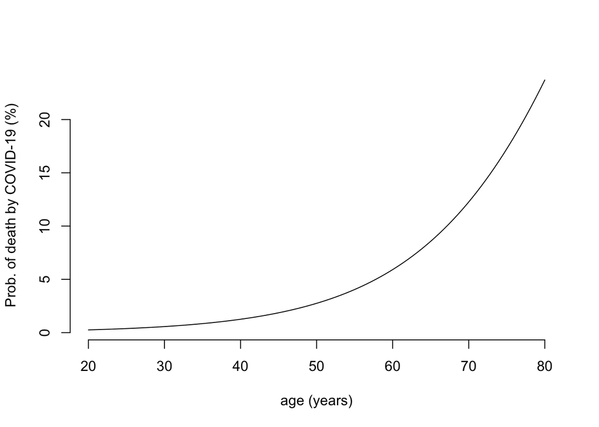

```r
curve(100 * get_prob_of_death(x), from = 20, to = 80,
      xlab = "age (years)", ylab = "Prob. of death by COVID-19 (%)", frame = F)
```

## Combined effects of Age and Sex

```r
d_age_sex <- d |> transmute(death_status, age_decades = age / 10, gender)
```

### Age + Sex

```r
logistic_age_sex <-
  glm(death_status ~ age_decades + gender, data = d_age_sex, family = "binomial") |>
  tidy(conf.int = TRUE)
logistic_age_sex
```

```
## # A tibble: 3 × 7
##   term        estimate std.error statistic  p.value conf.low conf.high
##   <chr>          <dbl>     <dbl>     <dbl>    <dbl>    <dbl>     <dbl>
## 1 (Intercept)   -8.02     0.718     -11.2  5.92e-29   -9.51      -6.69
## 2 age_decades    0.805    0.0959      8.40 4.60e-17    0.625      1.00
## 3 gendermale     0.678    0.285       2.38 1.73e- 2    0.133      1.25
```

### Sex-specific age effects

```r
d_males <- filter(d_age_sex, gender == "male")
glm(death_status ~ age_decades, data = d_males, family = "binomial") |>
  tidy(conf.int = TRUE) |>
  mutate(
    OR = exp(estimate),
    OR.L95 = exp(conf.low),
    OR.U95 = exp(conf.high)
  )
```

```
## # A tibble: 2 × 10
##   term  estim…¹ std.e…² stati…³  p.value conf.…⁴ conf.…⁵      OR  OR.L95  OR.U95
##   <chr>   <dbl>   <dbl>   <dbl>    <dbl>   <dbl>   <dbl>   <dbl>   <dbl>   <dbl>
## 1 (Int…  -6.85    0.780   -8.78 1.71e-18  -8.48   -5.42  0.00106 2.07e-4 0.00444
## 2 age_…   0.731   0.116    6.31 2.72e-10   0.514   0.969 2.08    1.67e+0 2.63
## # … with abbreviated variable names ¹estimate, ²std.error, ³statistic,
## #   ⁴conf.low, ⁵conf.high
```

```r
d_females <- filter(d_age_sex, gender == "female")
glm(death_status ~ age_decades, data = d_females, family = "binomial") |>
  tidy(conf.int = TRUE) |>
  mutate(
    OR = exp(estimate),
    OR.L95 = exp(conf.low),
    OR.U95 = exp(conf.high)
  )
```

```
## # A tibble: 2 × 10
##   term  estim…¹ std.e…² stati…³  p.value conf.…⁴ conf.…⁵      OR  OR.L95  OR.U95
##   <chr>   <dbl>   <dbl>   <dbl>    <dbl>   <dbl>   <dbl>   <dbl>   <dbl>   <dbl>
## 1 (Int…  -9.05    1.27    -7.10 1.23e-12 -11.8     -6.79 1.17e-4 7.42e-6 0.00113
## 2 age_…   0.949   0.172    5.52 3.45e- 8   0.635    1.31 2.58e+0 1.89e+0 3.72
## # … with abbreviated variable names ¹estimate, ²std.error, ³statistic,
## #   ⁴conf.low, ⁵conf.high
```

### Testing the difference between sex-specific age effects

```r
glm(death_status ~ age_decades + gender + age_decades:gender,
    data = d_age_sex, family = "binomial") |>
  tidy(conf.int = TRUE) |>
  mutate(
    OR = exp(estimate),
    OR.L95 = exp(conf.low),
    OR.U95 = exp(conf.high)
  )
```

```
## # A tibble: 4 × 10
##   term  estim…¹ std.e…² stati…³  p.value conf.…⁴ conf.…⁵      OR  OR.L95  OR.U95
##   <chr>   <dbl>   <dbl>   <dbl>    <dbl>   <dbl>   <dbl>   <dbl>   <dbl>   <dbl>
## 1 (Int…  -9.05    1.27    -7.10 1.23e-12 -11.8    -6.79  1.17e-4 7.42e-6 1.13e-3
## 2 age_…   0.949   0.172    5.52 3.45e- 8   0.635   1.31  2.58e+0 1.89e+0 3.72e+0
## 3 gend…   2.20    1.49     1.48 1.40e- 1  -0.598   5.31  9.06e+0 5.50e-1 2.03e+2
## 4 age_…  -0.218   0.207   -1.05 2.93e- 1  -0.641   0.177 8.04e-1 5.27e-1 1.19e+0
## # … with abbreviated variable names ¹estimate, ²std.error, ³statistic,
## #   ⁴conf.low, ⁵conf.high
```

## Beyond linear effects for Age

### Smoothing spline

```r
library(mgcv)
fit <- gam(death_status ~ s(age) + gender, data = d, family = "binomial")
```

```r
summary(fit)
```

```
##
## Family: binomial
## Link function: logit
##
## Formula:
## death_status ~ s(age) + gender
##
## Parametric coefficients:
##             Estimate Std. Error z value Pr(>|z|)
## (Intercept)  -3.9889     0.3057  -13.05   <2e-16 ***
## gendermale    0.6775     0.2847    2.38   0.0173 *
## ---
## Signif. codes:  0 '***' 0.001 '**' 0.01 '*' 0.05 '.' 0.1 ' ' 1
##
## Approximate significance of smooth terms:
##          edf Ref.df Chi.sq p-value
## s(age) 1.001  1.001  70.46  <2e-16 ***
## ---
## Signif. codes:  0 '***' 0.001 '**' 0.01 '*' 0.05 '.' 0.1 ' ' 1
##
## R-sq.(adj) =  0.108   Deviance explained = 19.7%
## UBRE = -0.62361  Scale est. = 1         n = 1123
```

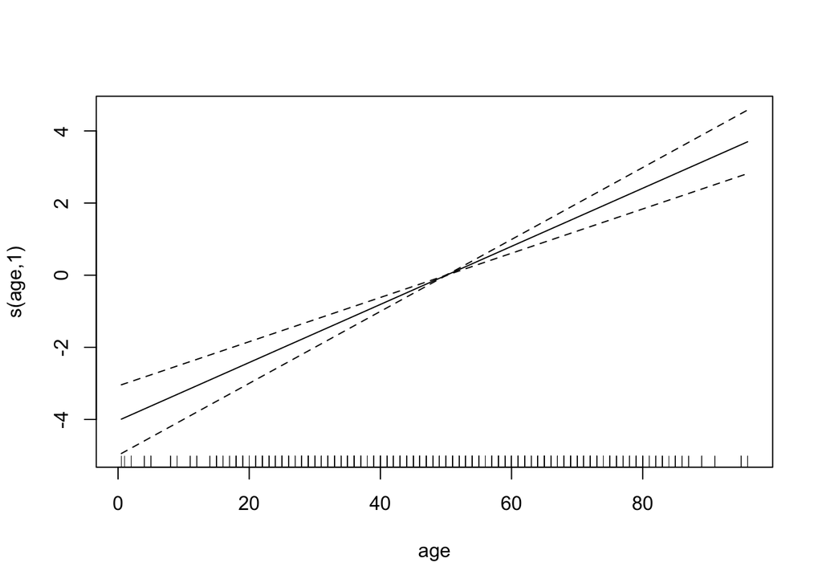

```r
plot(fit)
```

### Quadratic term

```r
#library(splines)
fit <- glm(death_status ~ age + I(age^2) + gender, data = d, family = "binomial")
summary(fit)
```

```
##
## Call:
## glm(formula = death_status ~ age + I(age^2) + gender, family = "binomial",
##     data = d)
##
## Deviance Residuals:
##      Min        1Q    Median        3Q       Max
## -1.00489  -0.35360  -0.21488  -0.09989   3.02335
##
## Coefficients:
##               Estimate Std. Error z value Pr(>|z|)
## (Intercept) -8.7267668  2.1625169  -4.035 5.45e-05 ***
## age          0.1037575  0.0671292   1.546   0.1222
## I(age^2)    -0.0001795  0.0005108  -0.351   0.7253
## gendermale   0.6642088  0.2860080   2.322   0.0202 *
## ---
## Signif. codes:  0 '***' 0.001 '**' 0.01 '*' 0.05 '.' 0.1 ' ' 1
##
## (Dispersion parameter for binomial family taken to be 1)
##
##     Null deviance: 518.64  on 1122  degrees of freedom
## Residual deviance: 416.55  on 1119  degrees of freedom
##   (1186 observations deleted due to missingness)
## AIC: 424.55
##
## Number of Fisher Scoring iterations: 8
```

### Piece-wise linear terms

```r
d2 <- mutate(d, age_70 = ifelse(age > 70, age - 70, 0))
```

```r
fit <- glm(death_status ~ age + age_70, data = d2, family = "binomial")
summary(fit)
```

```
##
## Call:
## glm(formula = death_status ~ age + age_70, family = "binomial",
##     data = d2)
##
## Deviance Residuals:
##     Min       1Q   Median       3Q      Max
## -1.1295  -0.3689  -0.2019  -0.1027   3.1165
##
## Coefficients:
##             Estimate Std. Error z value Pr(>|z|)
## (Intercept) -8.00966    1.01229  -7.912 2.52e-15 ***
## age          0.08781    0.01641   5.350 8.78e-08 ***
## age_70      -0.02053    0.03363  -0.611    0.541
## ---
## Signif. codes:  0 '***' 0.001 '**' 0.01 '*' 0.05 '.' 0.1 ' ' 1
##
## (Dispersion parameter for binomial family taken to be 1)
##
##     Null deviance: 528.64  on 1158  degrees of freedom
## Residual deviance: 426.76  on 1156  degrees of freedom
##   (1150 observations deleted due to missingness)
## AIC: 432.76
##
## Number of Fisher Scoring iterations: 7
```

From 0 to 70:

```r
exp(coef(fit)[2])
```

```
##      age
## 1.091782
```

After 70:

```r
exp(sum(coef(fit)[2:3]))
```

```
## [1] 1.069591
```

### A different parametrization

```r
d3 <- mutate(d,
             age_l70 = ifelse(age <= 70, age, 70),
             age_g70 = ifelse(age > 70, age - 70, 0))
fit <- glm(death_status ~ age_l70 + age_g70, data = d3, family = "binomial")

summary(fit)
```

```
##
## Call:
## glm(formula = death_status ~ age_l70 + age_g70, family = "binomial",
##     data = d3)
##
## Deviance Residuals:
##     Min       1Q   Median       3Q      Max
## -1.1295  -0.3689  -0.2019  -0.1027   3.1165
##
## Coefficients:
##             Estimate Std. Error z value Pr(>|z|)
## (Intercept) -8.00966    1.01229  -7.912 2.52e-15 ***
## age_l70      0.08781    0.01641   5.350 8.78e-08 ***
## age_g70      0.06728    0.02258   2.979  0.00289 **
## ---
## Signif. codes:  0 '***' 0.001 '**' 0.01 '*' 0.05 '.' 0.1 ' ' 1
##
## (Dispersion parameter for binomial family taken to be 1)
##
##     Null deviance: 528.64  on 1158  degrees of freedom
## Residual deviance: 426.76  on 1156  degrees of freedom
##   (1150 observations deleted due to missingness)
## AIC: 432.76
##
## Number of Fisher Scoring iterations: 7
```

```r
exp(confint(fit)[2:3,])
```

```
##            2.5 %   97.5 %
## age_l70 1.059790 1.130579
## age_g70 1.022768 1.118000
```

```r
exp(logistic_age_sex$estimate)
```

```
## [1] 0.0003285401 2.2374700990 1.9689546787
```

# Continuous outcome: survival time

## Data Preparation

```r
as_date <- function(x) as.Date(x, format = "%m/%d/%y")
d_raw <- read_csv(
  file = "covid19.csv",
  col_types = cols(
    id = 'c',
    case_in = 'c',
    age = 'd',
    if_onset_approximated = 'l',
    international_traveler = 'l',
    domestic_traveler = 'l',
    traveler = 'l',
    `visiting Wuhan` = 'l',
    `from Wuhan` = 'l',
    .default = 'c'
  )
)
d <-
  d_raw |>
  mutate(reporting_date = as_date(reporting_date),
         hosp_visit_date = as_date(hosp_visit_date),
         exposure_start = as_date(exposure_start),
         exposure_end = as_date(exposure_end),
         symptom_onset = as_date(symptom_onset),
         death_status = death != "0",
         death_date = as.Date(ifelse(!death %in% c("0", "1"), as.Date(death, format = "%m/%d/%y", origin = "1970-01-01"), NA), origin = "1970-01-01"),
         gender = factor(gender, levels = c("female", "male")))
```

The measured duration will be from first symptom to date of data collection: March 10th, 2020

```r
names(d)
```

```
##  [1] "id"                     "case_in"                "reporting_date"
##  [4] "summary"                "location"               "country"
##  [7] "gender"                 "age"                    "symptom_onset"
## [10] "if_onset_approximated"  "hosp_visit_date"        "exposure_start"
## [13] "exposure_end"           "international_traveler" "domestic_traveler"
## [16] "traveler"               "visiting Wuhan"         "from Wuhan"
## [19] "death"                  "recovered"              "symptom"
## [22] "source"                 "link"                   "death_status"
## [25] "death_date"
```

```r
d
```

```
## # A tibble: 2,310 × 25
##    id    case_in reporting_date summary  locat…¹ country gender   age symptom_…²
##    <chr> <chr>   <date>         <chr>    <chr>   <chr>   <fct>  <dbl> <date>
##  1 1     <NA>    2020-01-20     First c… Shenzh… China   male      66 2020-01-03
##  2 2     <NA>    2020-01-20     First c… Shangh… China   female    56 2020-01-15
##  3 3     <NA>    2020-01-21     First c… Zhejia… China   male      46 2020-01-04
##  4 4     <NA>    2020-01-21     new con… Tianjin China   female    60 NA
##  5 5     <NA>    2020-01-21     new con… Tianjin China   male      58 NA
##  6 6     <NA>    2020-01-21     First c… Chongq… China   female    44 2020-01-15
##  7 7     <NA>    2020-01-21     First c… Sichuan China   male      34 2020-01-11
##  8 8     <NA>    2020-01-21     new con… Beijing China   male      37 2020-01-14
##  9 9     <NA>    2020-01-21     new con… Beijing China   male      39 2020-01-09
## 10 10    <NA>    2020-01-21     new con… Beijing China   male      56 2020-01-16
## # … with 2,300 more rows, 16 more variables: if_onset_approximated <lgl>,
## #   hosp_visit_date <date>, exposure_start <date>, exposure_end <date>,
## #   international_traveler <lgl>, domestic_traveler <lgl>, traveler <lgl>,
## #   `visiting Wuhan` <lgl>, `from Wuhan` <lgl>, death <chr>, recovered <chr>,
## #   symptom <chr>, source <chr>, link <chr>, death_status <lgl>,
## #   death_date <date>, and abbreviated variable names ¹location, ²symptom_onset
```

```r
library(survival)
END_OF_STUDY <- as.Date("2020-03-10", format = "%Y-%m-%d", origin = "1970-01-01")
```

```r
d_surv <-
  d %>%
  filter(!is.na(symptom_onset), !is.na(death_status),
         !(is.na(death_date) & death_status)) %>%
  mutate(
    death_date = as.Date(ifelse(is.na(death_date), END_OF_STUDY, death_date), origin = "1970-01-01"),
    time = difftime(death_date, symptom_onset, units = "days")
  )
```

```r
d_surv |>
  select(symptom_onset, death_date, time, death_status) |>
  head(10) |>
  print()
```

```
## # A tibble: 10 × 4
##    symptom_onset death_date time    death_status
##    <date>        <date>     <drtn>  <lgl>
##  1 2020-01-03    2020-03-10 67 days FALSE
##  2 2020-01-15    2020-03-10 55 days FALSE
##  3 2020-01-04    2020-03-10 66 days FALSE
##  4 2020-01-15    2020-03-10 55 days FALSE
##  5 2020-01-11    2020-03-10 59 days FALSE
##  6 2020-01-14    2020-03-10 56 days FALSE
##  7 2020-01-09    2020-03-10 61 days FALSE
##  8 2020-01-16    2020-03-10 54 days FALSE
##  9 2020-01-19    2020-03-10 51 days FALSE
## 10 2020-01-15    2020-03-10 55 days FALSE
```

```r
fit <- survfit(Surv(time, death_status) ~ 1, data = d_surv)
fit
```

```
## Call: survfit(formula = Surv(time, death_status) ~ 1, data = d_surv)
##
##        n events median 0.95LCL 0.95UCL
## [1,] 623      7     NA      NA      NA
```

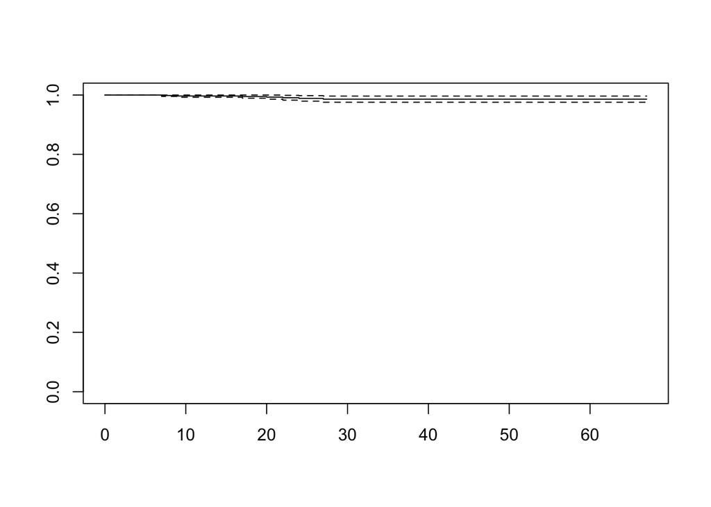

```r
plot(fit)
```

Let’s zoom in:

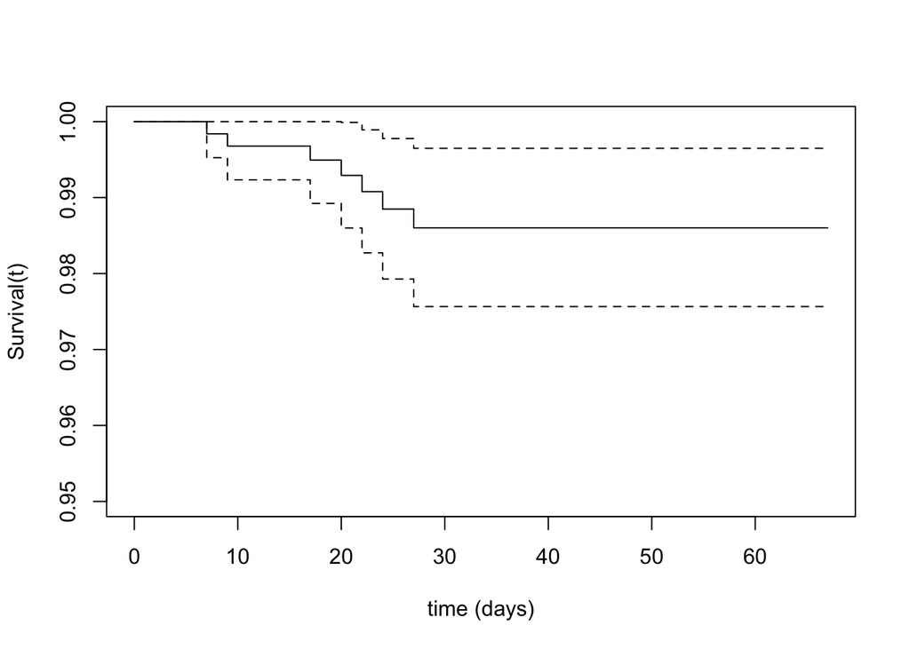

```r
plot(fit, ylim = c(0.95, 1),
     xlab = "time (days)", ylab = "Survival(t)")
```

Cannot extract a median, 7 deaths out of 623 cases (~1.1%):

```r
fit
```

```
## Call: survfit(formula = Surv(time, death_status) ~ 1, data = d_surv)
##
##        n events median 0.95LCL 0.95UCL
## [1,] 623      7     NA      NA      NA
```

## Effect of sex

```r
fit <- survfit(Surv(time, death_status) ~ gender, data = d_surv)
fit
```

```
## Call: survfit(formula = Surv(time, death_status) ~ gender, data = d_surv)
##
##    6 observations deleted due to missingness
##                 n events median 0.95LCL 0.95UCL
## gender=female 252      1     NA      NA      NA
## gender=male   365      5     NA      NA      NA
```

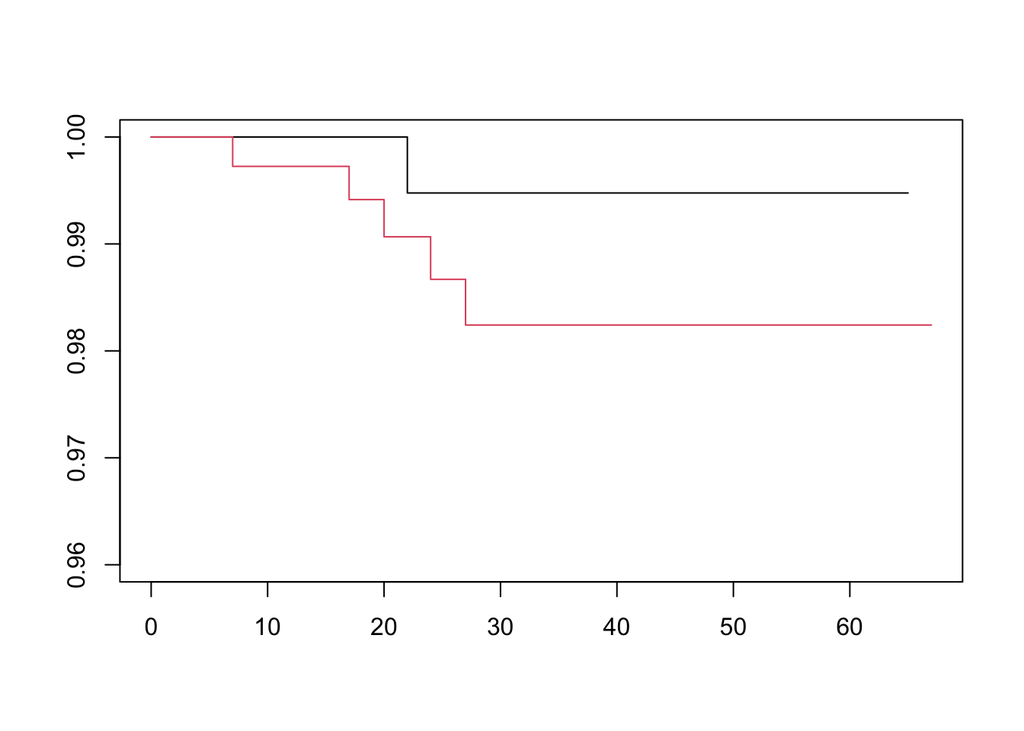

```r
plot(fit, col = 1:2, ylim = c(0.96, 1))
```

```r
survdiff(Surv(time, death_status) ~ gender, data = d_surv)
```

```
## Call:
## survdiff(formula = Surv(time, death_status) ~ gender, data = d_surv)
##
## n=617, 6 observations deleted due to missingness.
##
##                 N Observed Expected (O-E)^2/E (O-E)^2/V
## gender=female 252        1     2.48     0.880       1.5
## gender=male   365        5     3.52     0.618       1.5
##
##  Chisq= 1.5  on 1 degrees of freedom, p= 0.2
```

The p-value is large (p=0.2): the difference *is not* statistically significant.

```r
fit.cph <- coxph(Surv(time, death_status) ~ gender, data = d_surv)
summary(fit.cph)
```

```
## Call:
## coxph(formula = Surv(time, death_status) ~ gender, data = d_surv)
##
##   n= 617, number of events= 6
##    (6 observations deleted due to missingness)
##
##             coef exp(coef) se(coef)     z Pr(>|z|)
## gendermale 1.256     3.513    1.095 1.147    0.251
##
##            exp(coef) exp(-coef) lower .95 upper .95
## gendermale     3.513     0.2847    0.4104     30.07
##
## Concordance= 0.628  (se = 0.073 )
## Likelihood ratio test= 1.68  on 1 df,   p=0.2
## Wald test            = 1.32  on 1 df,   p=0.3
## Score (logrank) test = 1.5  on 1 df,   p=0.2
```

```r
d1 <- mutate(d_surv, age_dec = age / 10)
fit.cph <- coxph(Surv(time, death_status) ~ I(age/10), data = d1)
summary(fit.cph)
```

```
## Call:
## coxph(formula = Surv(time, death_status) ~ I(age/10), data = d1)
##
##   n= 605, number of events= 6
##    (18 observations deleted due to missingness)
##
##             coef exp(coef) se(coef)     z Pr(>|z|)
## I(age/10) 1.2403    3.4567   0.3435 3.611 0.000305 ***
## ---
## Signif. codes:  0 '***' 0.001 '**' 0.01 '*' 0.05 '.' 0.1 ' ' 1
##
##           exp(coef) exp(-coef) lower .95 upper .95
## I(age/10)     3.457     0.2893     1.763     6.777
##
## Concordance= 0.846  (se = 0.117 )
## Likelihood ratio test= 17.18  on 1 df,   p=3e-05
## Wald test            = 13.04  on 1 df,   p=3e-04
## Score (logrank) test = 14.43  on 1 df,   p=1e-04
```

## Age AND Sex

```r
fit.cph <- coxph(Surv(time, death_status) ~ age_dec + gender, data = d1)
summary(fit.cph)
```

```
## Call:
## coxph(formula = Surv(time, death_status) ~ age_dec + gender,
##     data = d1)
##
##   n= 604, number of events= 6
##    (19 observations deleted due to missingness)
##
##              coef exp(coef) se(coef)     z Pr(>|z|)
## age_dec    1.4149    4.1159   0.4034 3.507 0.000453 ***
## gendermale 1.8380    6.2840   1.1234 1.636 0.101806
## ---
## Signif. codes:  0 '***' 0.001 '**' 0.01 '*' 0.05 '.' 0.1 ' ' 1
##
##            exp(coef) exp(-coef) lower .95 upper .95
## age_dec        4.116     0.2430    1.8667     9.075
## gendermale     6.284     0.1591    0.6951    56.814
##
## Concordance= 0.872  (se = 0.096 )
## Likelihood ratio test= 20.8  on 2 df,   p=3e-05
## Wald test            = 13.1  on 2 df,   p=0.001
## Score (logrank) test = 16.58  on 2 df,   p=3e-04
```

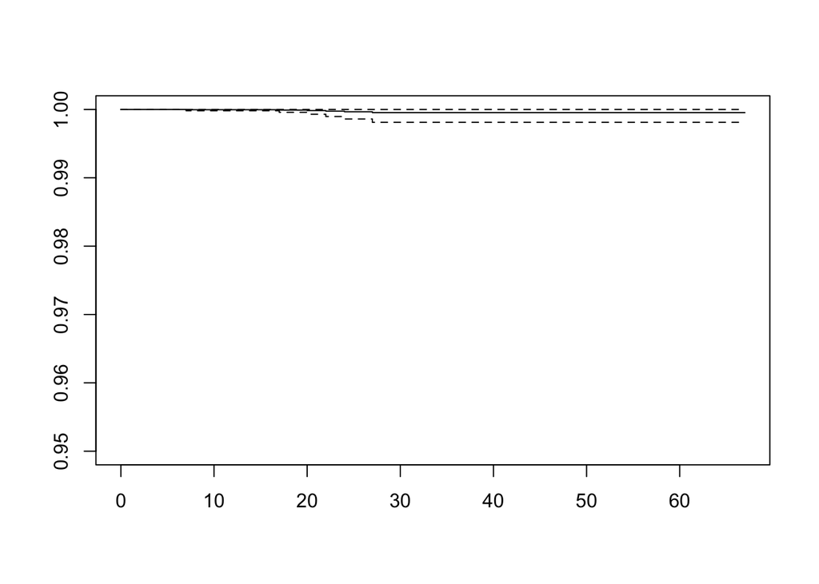

```r
data_new <- data.frame(age_dec = 6.3, gender = "male")
pred <- survfit(fit.cph, new.data = data_new)
plot(pred, ylim = c(0.95, 1.0))
```

```r
summary(pred, time = 30)
```

```
## Call: survfit(formula = fit.cph, new.data = data_new)
##
##  time n.risk n.event survival  std.err lower 95% CI upper 95% CI
##    30    353       6        1 0.000726        0.998            1
```

## Country

```r
nrow(d_surv)
```

```
## [1] 623
```

```r
table(d_surv$country)
```

```
##
##   Australia    Cambodia      Canada       China     Finland      France
##           9           1           2         111           1           5
##     Germany   Hong Kong       Italy       Japan    Malaysia       Nepal
##          14          81           1         222          10           1
## Phillipines   Singapore South Korea       Spain   Sri Lanka      Sweden
##           1          98          17           1           1           1
## Switzerland      Taiwan    Thailand         UAE         USA     Vietnam
##           2          23           7           1           8           5
```

### Countries with 50+ samples

```r
num_cases <- d_surv |> count(country) |> arrange(desc(n))
num_cases
```

```
## # A tibble: 24 × 2
##    country         n
##    <chr>       <int>
##  1 Japan         222
##  2 China         111
##  3 Singapore      98
##  4 Hong Kong      81
##  5 Taiwan         23
##  6 South Korea    17
##  7 Germany        14
##  8 Malaysia       10
##  9 Australia       9
## 10 USA             8
## # … with 14 more rows
```

```r
top_countries <- filter(num_cases, n >= 50)
d_tc <- d_surv |> semi_join(top_countries, by = "country")
table(d_tc$country)
```

```
##
##     China Hong Kong     Japan Singapore
##       111        81       222        98
```

```r
sfit <- survfit(Surv(time, death_status) ~ I(country == "Japan"), data = d_tc)
sfit
```

```
## Call: survfit(formula = Surv(time, death_status) ~ I(country == "Japan"),
##     data = d_tc)
##
##                               n events median 0.95LCL 0.95UCL
## I(country == "Japan")=FALSE 290      0     NA      NA      NA
## I(country == "Japan")=TRUE  222      5     NA      NA      NA
```

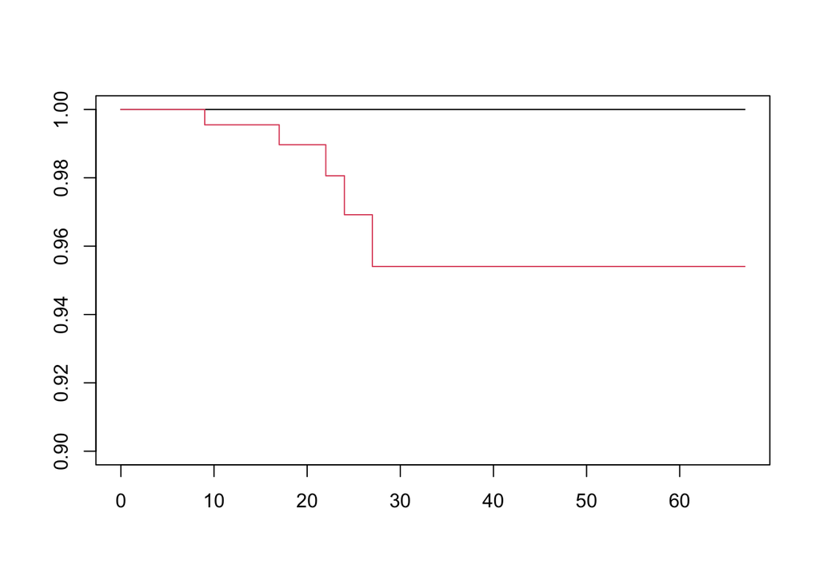

```r
plot(sfit, ylim = c(0.90, 1), col = 1:2)
```

```r
survdiff(Surv(time, death_status) ~ I(country == "Japan"), data = d_tc)
```

```
## Call:
## survdiff(formula = Surv(time, death_status) ~ I(country == "Japan"),
##     data = d_tc)
##
##                               N Observed Expected (O-E)^2/E (O-E)^2/V
## I(country == "Japan")=FALSE 290        0     3.42      3.42      11.2
## I(country == "Japan")=TRUE  222        5     1.58      7.45      11.2
##
##  Chisq= 11.2  on 1 degrees of freedom, p= 8e-04
```

```r
d_tc$japan <- (d_tc$country == "Japan") + 0
summary(coxph(Surv(time, death_status) ~ japan, data = d_tc))
```

```
## Call:
## coxph(formula = Surv(time, death_status) ~ japan, data = d_tc)
##
##   n= 512, number of events= 5
##
##            coef exp(coef)  se(coef)     z Pr(>|z|)
## japan 2.144e+01 2.039e+09 1.300e+04 0.002    0.999
##
##       exp(coef) exp(-coef) lower .95 upper .95
## japan 2.039e+09  4.904e-10         0       Inf
##
## Concordance= 0.836  (se = 0.022 )
## Likelihood ratio test= 11.91  on 1 df,   p=6e-04
## Wald test            = 0  on 1 df,   p=1
## Score (logrank) test = 11.24  on 1 df,   p=8e-04
```

### Compare by sex, stratifying by country

```r
survdiff(Surv(time, death_status) ~ gender + strata(I(country == "Japan")), data = d_tc)
```

```
## Call:
## survdiff(formula = Surv(time, death_status) ~ gender + strata(I(country ==
##     "Japan")), data = d_tc)
##
## n=510, 2 observations deleted due to missingness.
##
##                 N Observed Expected (O-E)^2/E (O-E)^2/V
## gender=female 211        1     1.39    0.1093     0.167
## gender=male   299        3     2.61    0.0582     0.167
##
##  Chisq= 0.2  on 1 degrees of freedom, p= 0.7
```

## Effects of covariates on risk of death

```r
summary(d_surv)
```

```
##       id              case_in          reporting_date         summary
##  Length:623         Length:623         Min.   :2020-01-13   Length:623
##  Class :character   Class :character   1st Qu.:2020-01-27   Class :character
##  Mode  :character   Mode  :character   Median :2020-02-14   Mode  :character
##                                        Mean   :2020-02-11
##                                        3rd Qu.:2020-02-25
##                                        Max.   :2020-03-06
##
##    location           country             gender         age
##  Length:623         Length:623         female:252   Min.   : 2.0
##  Class :character   Class :character   male  :365   1st Qu.:37.0
##  Mode  :character   Mode  :character   NA's  :  6   Median :52.0
##                                                     Mean   :50.3
##                                                     3rd Qu.:65.0
##                                                     Max.   :96.0
##                                                     NA's   :18
##  symptom_onset        if_onset_approximated hosp_visit_date
##  Min.   :2020-01-03   Mode :logical         Min.   :2020-01-06
##  1st Qu.:2020-01-23   FALSE:574             1st Qu.:2020-01-25
##  Median :2020-02-03   TRUE :24              Median :2020-02-06
##  Mean   :2020-02-04   NA's :25              Mean   :2020-02-07
##  3rd Qu.:2020-02-17                         3rd Qu.:2020-02-20
##  Max.   :2020-03-05                         Max.   :2020-03-02
##                                             NA's   :131
##  exposure_start        exposure_end        international_traveler
##  Min.   :2020-01-03   Min.   :2020-01-02   Mode :logical
##  1st Qu.:2020-01-12   1st Qu.:2020-01-17   FALSE:2
##  Median :2020-01-20   Median :2020-01-21   TRUE :5
##  Mean   :2020-02-02   Mean   :2020-01-22   NA's :616
##  3rd Qu.:2020-01-25   3rd Qu.:2020-01-23
##  Max.   :2020-12-29   Max.   :2020-03-04
##  NA's   :536          NA's   :407
##  domestic_traveler  traveler       visiting Wuhan  from Wuhan
##  Mode :logical     Mode :logical   Mode :logical   Mode :logical
##  FALSE:8           FALSE:57        FALSE:507       FALSE:543
##  NA's :615         TRUE :118       TRUE :116       TRUE :76
##                    NA's :448                       NA's :4
##
##
##
##     death            recovered           symptom             source
##  Length:623         Length:623         Length:623         Length:623
##  Class :character   Class :character   Class :character   Class :character
##  Mode  :character   Mode  :character   Mode  :character   Mode  :character
##
##
##
##
##      link           death_status      death_date             time
##  Length:623         Mode :logical   Min.   :2020-02-01   Length:623
##  Class :character   FALSE:616       1st Qu.:2020-03-10   Class :difftime
##  Mode  :character   TRUE :7         Median :2020-03-10   Mode  :numeric
##                                     Mean   :2020-03-09
##                                     3rd Qu.:2020-03-10
##                                     Max.   :2020-03-10
##
```

## Gender

```r
summary(coxph(Surv(time, death_status) ~ gender, data = d_surv))
```

```
## Call:
## coxph(formula = Surv(time, death_status) ~ gender, data = d_surv)
##
##   n= 617, number of events= 6
##    (6 observations deleted due to missingness)
##
##             coef exp(coef) se(coef)     z Pr(>|z|)
## gendermale 1.256     3.513    1.095 1.147    0.251
##
##            exp(coef) exp(-coef) lower .95 upper .95
## gendermale     3.513     0.2847    0.4104     30.07
##
## Concordance= 0.628  (se = 0.073 )
## Likelihood ratio test= 1.68  on 1 df,   p=0.2
## Wald test            = 1.32  on 1 df,   p=0.3
## Score (logrank) test = 1.5  on 1 df,   p=0.2
```

## Country

Model does not converge: again, too few cases.

```r
summary(coxph(Surv(time, death_status) ~ country, data = d_surv))
```

```
## Call:
## coxph(formula = Surv(time, death_status) ~ country, data = d_surv)
##
##   n= 623, number of events= 7
##
##                          coef  exp(coef)   se(coef)     z Pr(>|z|)
## countryCambodia    -3.535e-09  1.000e+00  7.851e+04  0.00        1
## countryCanada      -3.535e-09  1.000e+00  5.552e+04  0.00        1
## countryChina       -3.535e-09  1.000e+00  7.452e+03  0.00        1
## countryFinland     -3.535e-09  1.000e+00  7.851e+04  0.00        1
## countryFrance       2.131e+01  1.796e+09  1.101e+00 19.36   <2e-16 ***
## countryGermany      1.099e-01  1.116e+00  3.271e+04  0.00        1
## countryHong Kong    2.941e-02  1.030e+00  9.415e+03  0.00        1
## countryItaly        9.906e-02  1.104e+00  8.735e+04  0.00        1
## countryJapan        1.943e+01  2.747e+08  1.101e+00 17.66   <2e-16 ***
## countryMalaysia     1.626e-02  1.016e+00  2.531e+04  0.00        1
## countryNepal       -3.535e-09  1.000e+00  7.851e+04  0.00        1
## countryPhillipines  1.039e+02  1.279e+45  0.000e+00   Inf   <2e-16 ***
## countrySingapore    2.510e-02  1.025e+00  8.630e+03  0.00        1
## countrySouth Korea -3.535e-09  1.000e+00  1.904e+04  0.00        1
## countrySpain        5.117e-01  1.668e+00  2.048e+05  0.00        1
## countrySri Lanka   -3.535e-09  1.000e+00  7.851e+04  0.00        1
## countrySweden      -3.535e-09  1.000e+00  7.851e+04  0.00        1
## countrySwitzerland  1.929e-01  1.213e+00  6.996e+04  0.00        1
## countryTaiwan       3.256e-03  1.003e+00  1.668e+04  0.00        1
## countryThailand    -3.535e-09  1.000e+00  2.967e+04  0.00        1
## countryUAE         -3.535e-09  1.000e+00  7.851e+04  0.00        1
## countryUSA          1.008e-02  1.010e+00  2.934e+04  0.00        1
## countryVietnam     -3.535e-09  1.000e+00  3.511e+04  0.00        1
## ---
## Signif. codes:  0 '***' 0.001 '**' 0.01 '*' 0.05 '.' 0.1 ' ' 1
##
##                    exp(coef) exp(-coef) lower .95 upper .95
## countryCambodia    1.000e+00  1.000e+00 0.000e+00       Inf
## countryCanada      1.000e+00  1.000e+00 0.000e+00       Inf
## countryChina       1.000e+00  1.000e+00 0.000e+00       Inf
## countryFinland     1.000e+00  1.000e+00 0.000e+00       Inf
## countryFrance      1.796e+09  5.569e-10 2.077e+08 1.553e+10
## countryGermany     1.116e+00  8.959e-01 0.000e+00       Inf
## countryHong Kong   1.030e+00  9.710e-01 0.000e+00       Inf
## countryItaly       1.104e+00  9.057e-01 0.000e+00       Inf
## countryJapan       2.747e+08  3.640e-09 3.177e+07 2.375e+09
## countryMalaysia    1.016e+00  9.839e-01 0.000e+00       Inf
## countryNepal       1.000e+00  1.000e+00 0.000e+00       Inf
## countryPhillipines 1.279e+45  7.818e-46 1.279e+45 1.279e+45
## countrySingapore   1.025e+00  9.752e-01 0.000e+00       Inf
## countrySouth Korea 1.000e+00  1.000e+00 0.000e+00       Inf
## countrySpain       1.668e+00  5.995e-01 0.000e+00       Inf
## countrySri Lanka   1.000e+00  1.000e+00 0.000e+00       Inf
## countrySweden      1.000e+00  1.000e+00 0.000e+00       Inf
## countrySwitzerland 1.213e+00  8.246e-01 0.000e+00       Inf
## countryTaiwan      1.003e+00  9.967e-01 0.000e+00       Inf
## countryThailand    1.000e+00  1.000e+00 0.000e+00       Inf
## countryUAE         1.000e+00  1.000e+00 0.000e+00       Inf
## countryUSA         1.010e+00  9.900e-01 0.000e+00       Inf
## countryVietnam     1.000e+00  1.000e+00 0.000e+00       Inf
##
## Concordance= 0.904  (se = 0.029 )
## Likelihood ratio test= 31.22  on 23 df,   p=0.1
## Wald test            = 686.5  on 23 df,   p=<2e-16
## Score (logrank) test = 648.9  on 23 df,   p=<2e-16
```

Is risk in France really 1.8 **billion** times that in China?

## Age

This one is strong, as expected:

```r
summary(coxph(Surv(time, death_status) ~ I(age / 10), data = d_surv))
```

```
## Call:
## coxph(formula = Surv(time, death_status) ~ I(age/10), data = d_surv)
##
##   n= 605, number of events= 6
##    (18 observations deleted due to missingness)
##
##             coef exp(coef) se(coef)     z Pr(>|z|)
## I(age/10) 1.2403    3.4567   0.3435 3.611 0.000305 ***
## ---
## Signif. codes:  0 '***' 0.001 '**' 0.01 '*' 0.05 '.' 0.1 ' ' 1
##
##           exp(coef) exp(-coef) lower .95 upper .95
## I(age/10)     3.457     0.2893     1.763     6.777
##
## Concordance= 0.846  (se = 0.117 )
## Likelihood ratio test= 17.18  on 1 df,   p=3e-05
## Wald test            = 13.04  on 1 df,   p=3e-04
## Score (logrank) test = 14.43  on 1 df,   p=1e-04
```

## Age - pspline

```r
fit_age <- coxph(Surv(time, death_status) ~ pspline(age, df = 4), data = d_surv)
summary(fit_age)
```

```
## Call:
## coxph(formula = Surv(time, death_status) ~ pspline(age, df = 4),
##     data = d_surv)
##
##   n= 605, number of events= 6
##    (18 observations deleted due to missingness)
##
##                           coef  se(coef) se2     Chisq DF   p
## pspline(age, df = 4), lin 0.108 0.02791  0.02791 14.97 1.00 0.00011
## pspline(age, df = 4), non                         5.43 2.96 0.14000
##
##           exp(coef) exp(-coef) lower .95 upper .95
## ps(age)3  1.054e+01  9.488e-02 7.311e-08 1.519e+09
## ps(age)4  1.111e+02  9.003e-03 1.981e-13 6.227e+16
## ps(age)5  1.170e+03  8.545e-04 2.345e-17 5.839e+22
## ps(age)6  1.220e+04  8.197e-05 2.450e-19 6.073e+26
## ps(age)7  9.509e+04  1.052e-05 1.929e-19 4.688e+28
## ps(age)8  6.028e+04  1.659e-05 1.395e-19 2.604e+28
## ps(age)9  1.111e+04  9.002e-05 3.372e-20 3.660e+27
## ps(age)10 3.023e+04  3.308e-05 1.017e-19 8.980e+27
## ps(age)11 1.133e+06  8.824e-07 3.918e-18 3.278e+29
## ps(age)12 8.386e+06  1.193e-07 2.915e-17 2.413e+30
## ps(age)13 2.107e+06  4.747e-07 6.324e-18 7.017e+29
## ps(age)14 3.024e+05  3.306e-06 3.371e-19 2.713e+29
##
## Iterations: 4 outer, 18 Newton-Raphson
##      Theta= 0.03932137
## Degrees of freedom for terms= 4
## Concordance= 0.95  (se = 0.029 )
## Likelihood ratio test= 25.26  on 3.96 df,   p=4e-05
```

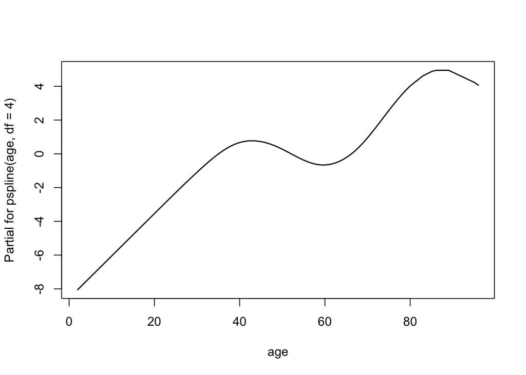

```r
termplot(fit_age, col.term = 1, col.se = 1)
```

## Age - piecewise-linear - A

Two segments: constant 0-70; increasing after 70

```r
e <-
  d_surv |>
  mutate(
    age_70p = ifelse(age <= 70, 0, age - 70)
  )
```

```r
fit_age_segments <- coxph(Surv(time, death_status) ~ age_70p, data = e)
summary(fit_age_segments)
```

```
## Call:
## coxph(formula = Surv(time, death_status) ~ age_70p, data = e)
##
##   n= 605, number of events= 6
##    (18 observations deleted due to missingness)
##
##            coef exp(coef) se(coef)    z Pr(>|z|)
## age_70p 0.21373   1.23828  0.04063 5.26 1.44e-07 ***
## ---
## Signif. codes:  0 '***' 0.001 '**' 0.01 '*' 0.05 '.' 0.1 ' ' 1
##
##         exp(coef) exp(-coef) lower .95 upper .95
## age_70p     1.238     0.8076     1.144     1.341
##
## Concordance= 0.866  (se = 0.1 )
## Likelihood ratio test= 16.43  on 1 df,   p=5e-05
## Wald test            = 27.67  on 1 df,   p=1e-07
## Score (logrank) test = 66.68  on 1 df,   p=3e-16
```

Or more simply, before and after 70:

```r
fit_age_binary <- coxph(Surv(time, death_status) ~ I(age > 70), data = e)
summary(fit_age_binary)
```

```
## Call:
## coxph(formula = Surv(time, death_status) ~ I(age > 70), data = e)
##
##   n= 605, number of events= 6
##    (18 observations deleted due to missingness)
##
##                   coef exp(coef) se(coef)     z Pr(>|z|)
## I(age > 70)TRUE  3.694    40.200    1.097 3.368 0.000756 ***
## ---
## Signif. codes:  0 '***' 0.001 '**' 0.01 '*' 0.05 '.' 0.1 ' ' 1
##
##                 exp(coef) exp(-coef) lower .95 upper .95
## I(age > 70)TRUE      40.2    0.02488     4.686     344.9
##
## Concordance= 0.839  (se = 0.093 )
## Likelihood ratio test= 16.79  on 1 df,   p=4e-05
## Wald test            = 11.35  on 1 df,   p=8e-04
## Score (logrank) test = 31.52  on 1 df,   p=2e-08
```

Risk after 70yo is **40 times** that of people less than 70yo! Let’s see it visually:

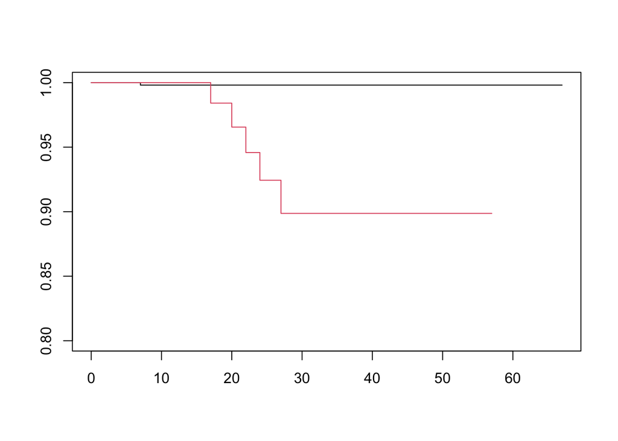

```r
e$x <- factor(ifelse(e$age > 70, ">70", "<=70"), levels = c("<=70", ">70"))
plot(survfit(Surv(time, death_status) ~ I(age > 70), data = e),
     ylim = c(0.8, 1),
     col = 1:2)
```

## Age - piecewise-linear - B

Two segments: b1 for 0-70; b2 after 70

```r
e <-
  d_surv |>
  mutate(
    age_le70 = ifelse(age <= 70, age, 70),
    age_gt70 = ifelse(age <= 70, 0, age - 70)
  )
```

```r
with(e, table(age == (age_le70 + age_gt70)))
```

```
##
## TRUE
##  605
```

```r
fit_age_segments <- coxph(Surv(time, death_status) ~ age_le70 + age_gt70, data = e)
summary(fit_age_segments)
```

```
## Call:
## coxph(formula = Surv(time, death_status) ~ age_le70 + age_gt70,
##     data = e)
##
##   n= 605, number of events= 6
##    (18 observations deleted due to missingness)
##
##             coef exp(coef) se(coef)     z Pr(>|z|)
## age_le70 0.06359   1.06566  0.05434 1.170 0.241889
## age_gt70 0.17023   1.18557  0.05156 3.301 0.000962 ***
## ---
## Signif. codes:  0 '***' 0.001 '**' 0.01 '*' 0.05 '.' 0.1 ' ' 1
##
##          exp(coef) exp(-coef) lower .95 upper .95
## age_le70     1.066     0.9384     0.958     1.185
## age_gt70     1.186     0.8435     1.072     1.312
##
## Concordance= 0.846  (se = 0.117 )
## Likelihood ratio test= 18.36  on 2 df,   p=1e-04
## Wald test            = 21.78  on 2 df,   p=2e-05
## Score (logrank) test = 66.91  on 2 df,   p=3e-15
```

The positive effect of age on risk of death by Covid-19 is only statistically significant *after* age=70.

```r
pl_age <- function(x) {
  cbind(
    age_le70 = ifelse(x <= 70, x, 70),
    age_gt70 = ifelse(x <= 70, 0, x - 70)
  )
}
pl_age(65:75)
```

```
##       age_le70 age_gt70
##  [1,]       65        0
##  [2,]       66        0
##  [3,]       67        0
##  [4,]       68        0
##  [5,]       69        0
##  [6,]       70        0
##  [7,]       70        1
##  [8,]       70        2
##  [9,]       70        3
## [10,]       70        4
## [11,]       70        5
```

```r
(b <- coef(fit_age_segments))
```

```
##   age_le70   age_gt70
## 0.06358991 0.17022727
```

```r
linear_predictor <- function(age) {
  X <- pl_age(age)
  X %*% b
}
linear_predictor(65:75)
```

```
##           [,1]
##  [1,] 4.133344
##  [2,] 4.196934
##  [3,] 4.260524
##  [4,] 4.324114
##  [5,] 4.387704
##  [6,] 4.451294
##  [7,] 4.621521
##  [8,] 4.791748
##  [9,] 4.961976
## [10,] 5.132203
## [11,] 5.302430
```

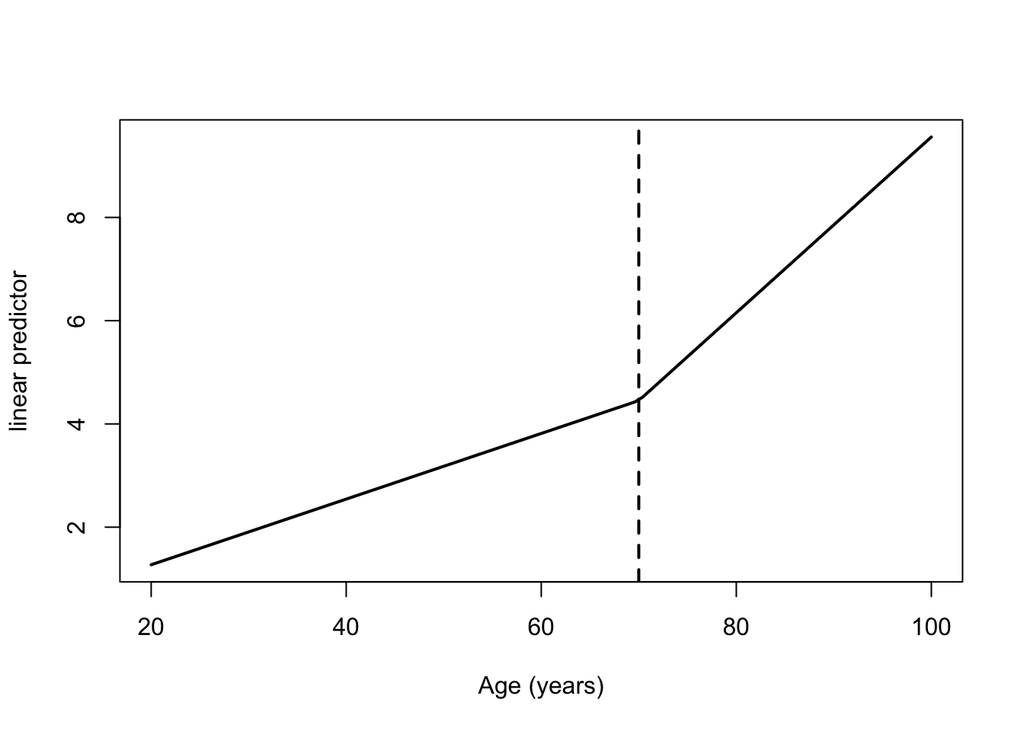

```r
curve(linear_predictor(x), from = 20, to = 100,
      lwd = 2,
      xlab = "Age (years)",
      ylab = "linear predictor")
abline(v = 70, lty = 2, lwd = 2)
```